# Statistical Analysis Project

## by Yanyan Liu

```python
import pandas as pd
import numpy as np
import math
df = pd.read_csv("stroopdata.csv")
df.head()
```

|  | Congruent | Incongruent |
| --- | --- | --- |
| 0 | 12.079 | 19.278 |
| 1 | 16.791 | 18.741 |
| 2 | 9.564 | 21.214 |
| 3 | 8.630 | 15.687 |
| 4 | 14.669 | 22.803 |

## Question 1

### What is our independent variable? What is our dependent variable?

**Answer**: different kinds of stimuli, incongruent or congruent, are independent variables; dependent variables: the time the participating person takes to name the ink colors

## Question2

### What is an appropriate set of hypotheses for this task? What kind of statistical test do you expect to perform? Justify your choices

**Answer**:

- For this task, we are using a sample in order to make inferences about the population, that is unknown, to find whether there is a difference between congruent and incongruent means in the population.
- H0: μC = μI
- HA: μC != μI
- the null hypothsis says: there is no time difference, the population of times for naming the ink colors under congruent stimulus are no different from the population of the times for naming the ink color under incongruent stimulus. That is there is no difference in the two response time population mean.
- The alternative hypothsis says: there is time difference, the population of times for naming the ink colors under congruent stimulus are different from the population of the times for naming the ink color under incongruent stimulus. That is there is difference in the two response time population mean.
- This is a two tailed paired T test, suppose that we do not know under which stimulus the population of response-time mean will be smaller. But if we have prio that under congruent stimulus, people take less time to name the ink color than that under uncongruent stimulus,that is the population of response-time mean will be smaller under congruent stimulus. In this case, it will be a one tailed T test
- if we know the population parameters, μ and /sigma, we can use Z test. In this case, we do not know these parameters, we have to estimate the population parameters based on samples. standard error are depending on samples, as we can not longer using /sigma. And in this case, we can not use Z distribution, we need to use T distribution
- In this experiment, the same person took the experiment twice, congruent and incongruent, and belongs to with-in subject design. This kind of experiment design produced paired data. We used paired T test in this case.

## Question 3.

### Report some descriptive statistics regarding this dataset. Include at least one measure of central tendency and at least one measure of variability.

```python
df.diff = df.Congruent - df.Incongruent
```

```python
# mean for central tendency
df.diff.mean()
```

```
-7.964791666666667
```

```python
# standard deviation for variability
df.diff.std(ddof=1)
```

```
4.864826910359056
```

**answer**

- mean for time difference between congruent and incongruent is -7.96
- standard deviation for the time difference between congruent and incongruent is 4.86

## Question 4.

### Provide one or two visualizations that show the distribution of the sample data. Write one or two sentences noting what you observe about the plot or plots

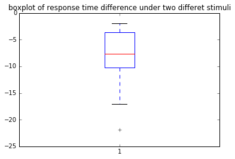

```python
import matplotlib.pyplot as plt
%matplotlib inline
plt.boxplot(df.diff)
plt.title("boxplot of response time difference under two differet stimuli")
plt.show()
```

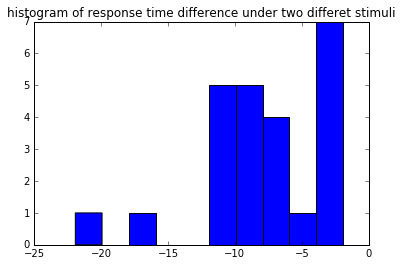

```python
plt.hist(df.diff)
plt.title("histogram of response time difference under two differet stimuli")
plt.show()
```

**Answer**:

- both box plot and histogram can be used to show the distribution of the data.
- As the total number of obervation is 24, it is kind of small, it is hard for histogram to show a clear bell curve shape, but the trend is there.
- The box plot can show the 25 percentile, median, and 75 percentile of the data, but hide more detailed info. The good thing about box plot is that it clearly shows outliers.

## Question 5

### Now, perform the statistical test and report your results. What is your confidence level and your critical statistic value? Do you reject the null hypothesis or fail to reject it? Come to a conclusion in terms of the experiment task. Did the results match up with your expectations?

```python
s=math.sqrt(np.sum(np.square((df.diff-df.diff.mean()).values))/(df.shape[0]-1))
```

```python
# standard error
SE = s/math.sqrt(df.shape[0])
print SE
```

```
0.993028634778
```

```python
# standard error
SE = s/math.sqrt(df.shape[0])
print SE
```

```
0.993028634778
```

```python
# t value
t = df.diff.mean()/SE
print t
```

```
-8.02070694411
```

```python
# degree of freedom
DF = df.shape[0]-1
print DF
```

```
23
```

```python
# confidence interval
diff=(df.values[:,0]-df.values[:,1]).mean()
low = diff - 2.069*SE
high = diff + 2.069*SE
print (low,high)
```

```
(-10.019367912023053, -5.9102154213102791)
```

**Answer**: